# MyHomework10

# 基本繪圖

## 敘述統計

除了前述的多種計算基本統計量的函數外，還有以下常用的： + `table(x)`：計算類別型資料的列聯表（contingency table）。 + `mad(x)`：計算平均絕對偏差（median absolute deviation）。 + `quantile(x)`：計算資料的各個分位數。

```
+ `fivenum(x)`：計算各個分位數的函數。
+ `summary(x)`：計算向量或 data frame 的一些基本統計量。
+ `cor(x, y)`：計算兩個向量之間的相關係數。
+ `cancor(x, y)`：計算更詳細的相關係數資料。
+ `cov(x, y)`：計算共變異數。
```

## 繪圖系統

Ｒ的繪圖系統大致可分為三大類：

1. `base` 與 `grid` 系統：base 是最早期的 R 繪圖系統，功能比較簡單、上手也很容易，但擴充性較差，若要繪製較複雜的圖形會有一些困難。而由於 base 繪圖系統在使用上有些限制，所以後來又發展出一套 grid 繪圖系統，它可以讓使用者以較低階的方式繪圖，例如繪製點、線或是方塊等，雖然 grid 的彈性很大，但是對於資料量比較大的圖形，要用這麼低階的方式畫圖還是會有困難。
2. `lattice` 系統：lattice 是根據 grid 為基礎所發展出來的一套繪圖系統，對於各種常見的圖形提供了比較高階的繪圖函數，跟傳統的 base 系統相較之下，lattice 主要有兩個特點：
- 所有的繪圖結果都可以儲存在變數當中（不像 base 是直接畫在螢幕上的），也就是說在 lattice 系統之下，使用者可以對畫出來的圖形做進一步的修改，然後再重新畫出新的結果，對於一系列相類似的圖組也可以使用這樣的技巧加速繪圖的速度，另外也可以把繪圖結果儲存下來，供日後使用。
- lattice 的第二個特色則是一張圖形中可以包含多個子繪圖區域，亦即使用者可以將多張子圖形直接放在同一張圖中一起比較，省去了自己手動合併多張圖形的困擾。
3. `ggplot2` 系統：ggplot2 也是一個以 grid 所發展出來的繪圖系統，承襲了 lattice 的兩大特色，並加入了繪圖文法的概念，其名稱中的 gg 所代表的是 grammar of graphics，意指將圖形拆解成許多組件的繪圖系統，語法與傳統式的單一函數呼叫繪圖有些不同，而其所產生的圖形也比前兩種繪圖系統美觀。

很不幸地這三種 R 繪圖系統在大部分的狀況下都不相容，雖然最新的 ggplot2 繪圖系統的功能相當完整，而且畫出的圖形也比較漂亮，多數的圖形都可以使用 ggplot2 來完成，但是由於舊的兩個繪圖系統已經在 R 中存在相當長一段時間，有非常大量的 R 套件在繪圖的功能上都是使用這兩個舊系統，所以在使用 R 時難免都會接觸到，所以還是對它們需要有基本的認識。

以下以散佈圖（Scatter Plots）為例：

`base` 系統

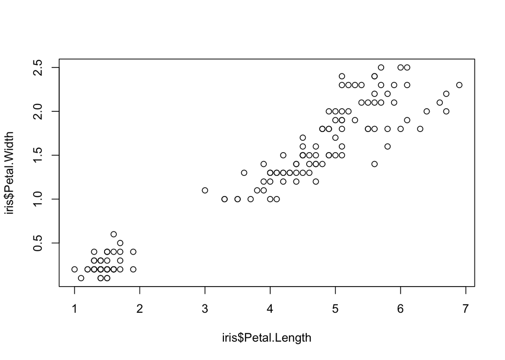

```r
plot(iris$Petal.Length, iris$Petal.Width)
```

`lattice`系統

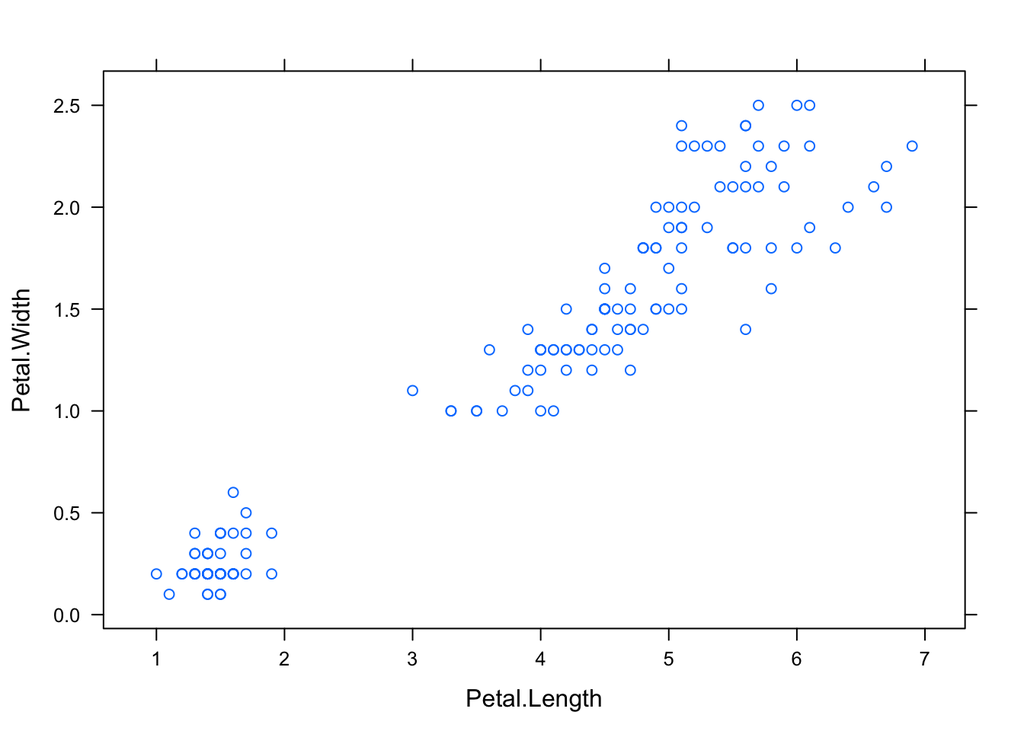

```r
library(lattice)
xyplot(Petal.Width ~ Petal.Length, iris)
```

`ggplot2`系統

ggplot2 的繪圖方式與以往的繪圖系統有一個根本上的差異，每一張圖都會以 ggplot 函數來建立基本的 ggplot 繪圖物件，並指定資料來源以及資料與圖形之間的對應關係，接著再用加號（+）連接後續的繪圖類型與細部參數：

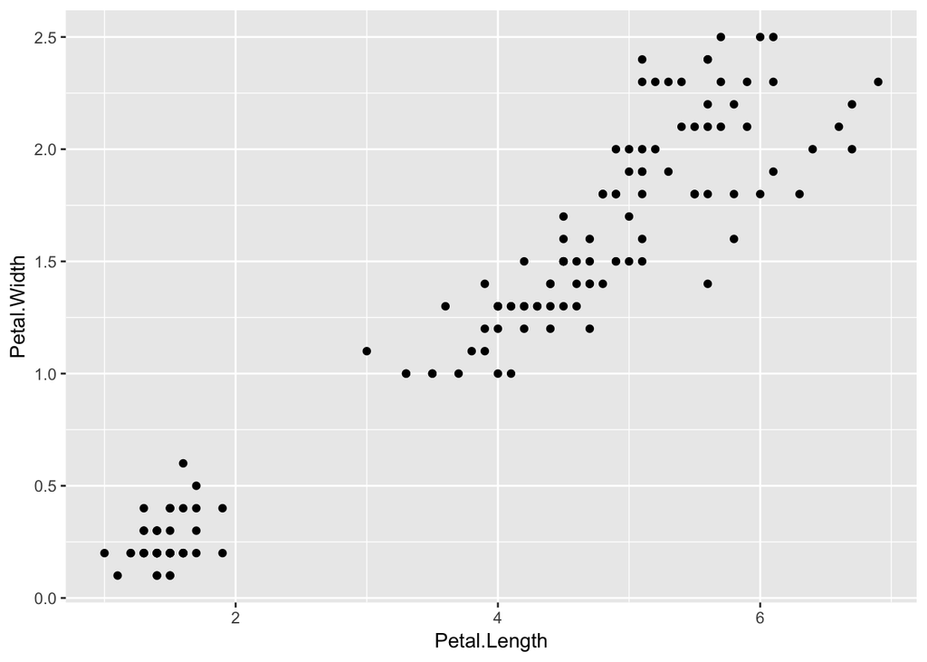

```r
library(ggplot2)
ggplot(iris, aes(x = Petal.Length, y = Petal.Width)) +
  geom_point()
```

又特別舉`ggplot2`的長條圖（barchart）為例：

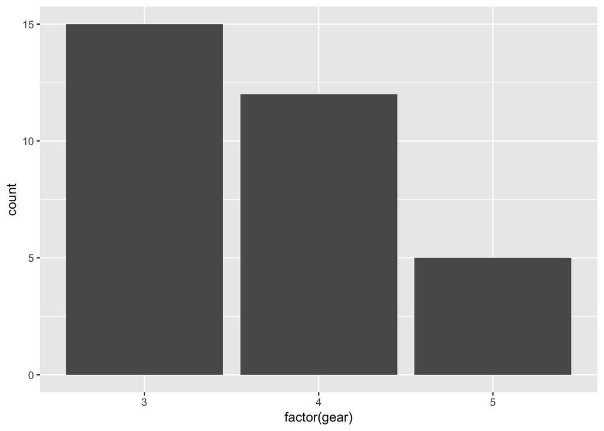

```r
ggplot(mtcars, aes(factor(gear))) +
  geom_bar()
```

水平的長條圖：

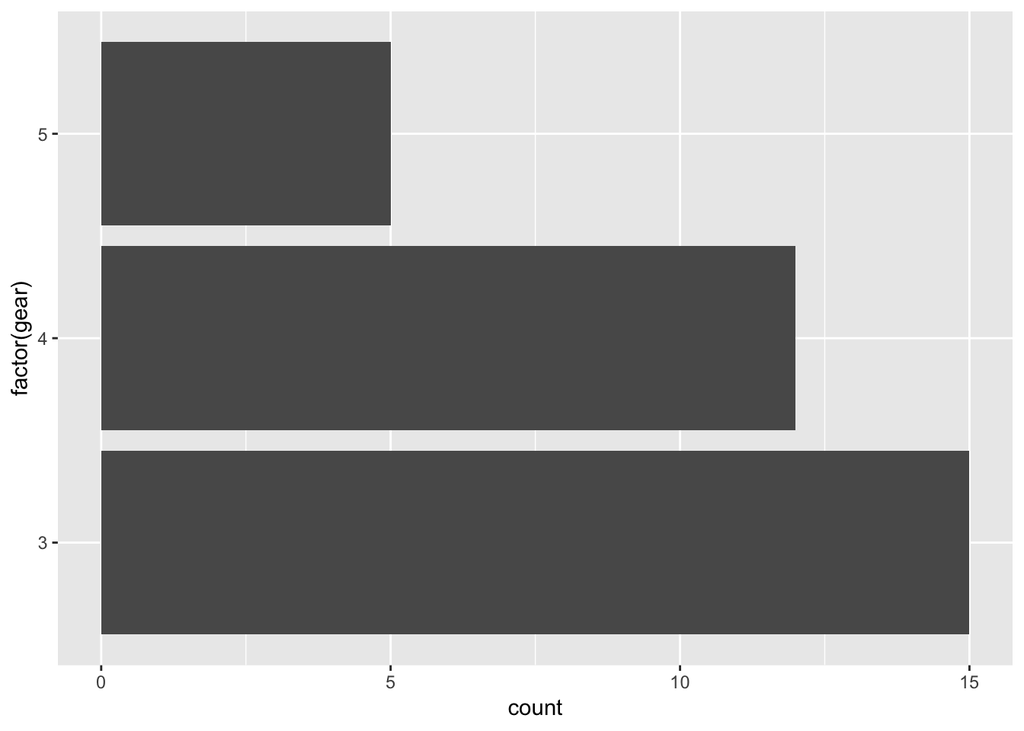

```r
ggplot(mtcars, aes(factor(gear))) +
  geom_bar() +
  coord_flip()
```

以不同顏色呈現不同資料：

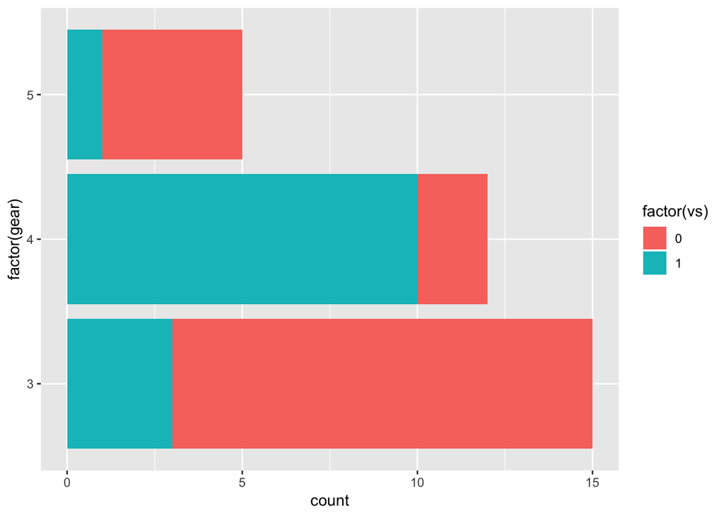

```r
ggplot(mtcars, aes(factor(gear), fill = factor(vs))) +
  geom_bar() +
  coord_flip()
```

讓長條圖並列顯示：

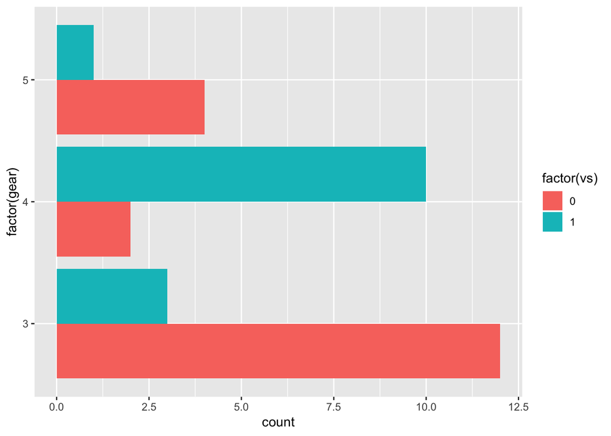

```r
ggplot(mtcars, aes(factor(gear), fill = factor(vs))) +
  geom_bar(position="dodge") +
  coord_flip()
```

- 大部分的 ggplot 的簡化圖層函數都有一些共通的參數：
  - `mapping`：指定美學對應，指定時需要以 `aes` 函數包裝，若沒有指定則會使用繪圖物件的預設值。
  - `data`：指定資料來源的 data frame，通常都會省略，並直接使用繪圖物件的預設值。
  - `...`：geom 與 stat 所使用的參數，例如直方圖的 bin 寬度等。
  - `geom`和`stat`：自行指定要使用的 geom 與 stat，改變預設的設定。
  - `position`：指定細部的資料位置調整。
- 一些基本繪圖函數：
  - `plot(x, y)`：畫出 x 與 y 的分佈圖（scatter plot）。
  - `lines(x, y)`：在圖形中加入線條。
  - `order(x)`：計算資料的排序向量。
  - `loess(y ~x)`：LOESS 平滑曲線。（M <- loess (y ~ x)）
  - `fitted (M)`：計算配適值。

# 類別資料

以Horseshoe Crabs的data為例：

logistic regression model：(以weight作為變數)

```r
crabs.logit <- glm((satell > 0) ~ weight, family=binomial, data=crabs)
summary(crabs.logit)
```

```
##
## Call:
## glm(formula = (satell > 0) ~ weight, family = binomial, data = crabs)
##
## Deviance Residuals:
##     Min       1Q   Median       3Q      Max
## -2.1108  -1.0749   0.5426   0.9122   1.6285
##
## Coefficients:
##             Estimate Std. Error z value Pr(>|z|)
## (Intercept)  -3.6947     0.8802  -4.198 2.70e-05 ***
## weight        1.8151     0.3767   4.819 1.45e-06 ***
## ---
## Signif. codes:  0 '***' 0.001 '**' 0.01 '*' 0.05 '.' 0.1 ' ' 1
##
## (Dispersion parameter for binomial family taken to be 1)
##
##     Null deviance: 225.76  on 172  degrees of freedom
## Residual deviance: 195.74  on 171  degrees of freedom
## AIC: 199.74
##
## Number of Fisher Scoring iterations: 4
```

```r
drop1(crabs.logit, test="Chisq")
```

```
## Single term deletions
##
## Model:
## (satell > 0) ~ weight
##        Df Deviance    AIC    LRT  Pr(>Chi)
## <none>      195.74 199.74
## weight  1   225.76 227.76 30.021 4.273e-08 ***
## ---
## Signif. codes:  0 '***' 0.001 '**' 0.01 '*' 0.05 '.' 0.1 ' ' 1
```

log-odds：

```r
xbar = mean(crabs$weight)  #以平均數為例
predict(crabs.logit, data.frame(weight=xbar), type="link")
```

```
##         1
## 0.7291272
```

```r
predict(crabs.logit, data.frame(weight=xbar), type="response")  #predicted probabilities
```

```
##         1
## 0.6746137
```

```r
crabs$color = factor(crabs$color, levels=c("light", "medium", "dark", "darker"))
crabs.fit1 <- glm((satell > 0) ~ color+ weight, family=binomial, data=crabs)
summary(crabs.fit1)
```

```
##
## Call:
## glm(formula = (satell > 0) ~ color + weight, family = binomial,
##     data = crabs)
##
## Deviance Residuals:
##     Min       1Q   Median       3Q      Max
## -2.1908  -1.0144   0.5101   0.8683   2.0751
##
## Coefficients:
##             Estimate Std. Error z value Pr(>|z|)
## (Intercept)  -3.2572     1.1985  -2.718  0.00657 **
## colormedium   0.1448     0.7365   0.197  0.84410
## colordark    -0.1861     0.7750  -0.240  0.81019
## colordarker  -1.2694     0.8488  -1.495  0.13479
## weight        1.6928     0.3888   4.354 1.34e-05 ***
## ---
## Signif. codes:  0 '***' 0.001 '**' 0.01 '*' 0.05 '.' 0.1 ' ' 1
##
## (Dispersion parameter for binomial family taken to be 1)
##
##     Null deviance: 225.76  on 172  degrees of freedom
## Residual deviance: 188.54  on 168  degrees of freedom
## AIC: 198.54
##
## Number of Fisher Scoring iterations: 4
```

```r
anova(crabs.logit, crabs.fit1, test="Chisq")
```

```
## Analysis of Deviance Table
##
## Model 1: (satell > 0) ~ weight
## Model 2: (satell > 0) ~ color + weight
##   Resid. Df Resid. Dev Df Deviance Pr(>Chi)
## 1       171     195.74
## 2       168     188.54  3   7.1949  0.06594 .
## ---
## Signif. codes:  0 '***' 0.001 '**' 0.01 '*' 0.05 '.' 0.1 ' ' 1
```

```r
drop1(crabs.fit1, test="Chisq")
```

```
## Single term deletions
##
## Model:
## (satell > 0) ~ color + weight
##        Df Deviance    AIC     LRT  Pr(>Chi)
## <none>      188.54 198.54
## color   3   195.74 199.74  7.1949   0.06594 .
## weight  1   212.06 220.06 23.5186 1.237e-06 ***
## ---
## Signif. codes:  0 '***' 0.001 '**' 0.01 '*' 0.05 '.' 0.1 ' ' 1
```

```r
crabs.fitWidth <- update(crabs.fit1, . ~ width)
y <- as.numeric(horseshoecrabs$satell > 0)

pihat <- predict(crabs.fitWidth, type="response")
cor(y,pihat)
```

```
## [1] 0.4019782
```